# Analysis of the Adverse Health and Economic Impacts of US Storms

Farina Fayyaz

2024-02-12

## 1. Synopsis

This research delves into the NOAA Storm Database, spanning 1950 to November 2011, to assess the impact of severe weather events on human health, property, and crops. Through detailed analysis, we aim to identify which types of events pose the greatest threat to  
1. Population 2. Economy measured by injuries, fatalities, and economic consequences.  
For more information about Data: [Documentation](https://github.com/FarinaFayyaz/datasciencecoursera/tree/main/05.%20Reproducible%20Research/Course%20Project%202)

## 2. Research Questions

1. Across the United States, which types of events are most harmful with respect to population health?
2. Across the United States, which types of events have the greatest economic consequences?

## 3. Data Processing

### 3.1. Downloading the Data

```r
if (!dir.exists("Data")) {
    dir.create("Data")
    url <- "https://d396qusza40orc.cloudfront.net/repdata%2Fdata%2FStormData.csv.bz2"
    download.file(url, destfile = "Data/data.csv")
}
```

### 3.2 Loading Data into R

```r
# Loading dependencies
library(data.table)
# Reading Data from .csv file
data <- read.csv("Data/data.csv")
# Converting to data.table
df <- as.data.table(data)
```

### 3.3 Identifying Column Names

```r
# Identifying Column Names
names(df)
```

```
##  [1] "STATE__"    "BGN_DATE"   "BGN_TIME"   "TIME_ZONE"  "COUNTY"
##  [6] "COUNTYNAME" "STATE"      "EVTYPE"     "BGN_RANGE"  "BGN_AZI"
## [11] "BGN_LOCATI" "END_DATE"   "END_TIME"   "COUNTY_END" "COUNTYENDN"
## [16] "END_RANGE"  "END_AZI"    "END_LOCATI" "LENGTH"     "WIDTH"
## [21] "F"          "MAG"        "FATALITIES" "INJURIES"   "PROPDMG"
## [26] "PROPDMGEXP" "CROPDMG"    "CROPDMGEXP" "WFO"        "STATEOFFIC"
## [31] "ZONENAMES"  "LATITUDE"   "LONGITUDE"  "LATITUDE_E" "LONGITUDE_"
## [36] "REMARKS"    "REFNUM"
```

### 3.4 Subsetting the Data

We only need to keep columns “EVTYPE”, “INJURIES”,“FATALITIES”,“PROPDMG”,“PROPDMGEXP”, “CROPDMG” and “CROPDMGEXP” for our analysis. Also, we’ll only use data where fatalities and injuries occurred.

```r
# Keep only necessary columns
desired_columns <- c("EVTYPE", "FATALITIES", "INJURIES", "PROPDMG",
    "PROPDMGEXP", "CROPDMG", "CROPDMGEXP")
stormdata <- df[, ..desired_columns]
# Select rows where either fatalities or injuries are
# greater than 0
subsetdf <- stormdata[stormdata$FATALITIES > 0 | stormdata$INJURIES >
    0, ]
```

### 3.5 Data Cleaning

To calculate Property Damage and Crop Cost we need to clean relevant columns

```r
# Change all damage exponents to uppercase.
cols <- c("PROPDMGEXP", "CROPDMGEXP")
subsetdf[, (cols) := lapply(.SD, toupper), .SDcols = cols]

# Map property damage alphanumeric exponents to numeric
# values.
propDmgKey <- c(`""` = 10^0, `-` = 10^0, `+` = 10^0, `0` = 10^0,
    `1` = 10^1, `2` = 10^2, `3` = 10^3, `4` = 10^4, `5` = 10^5,
    `6` = 10^6, `7` = 10^7, `8` = 10^8, `9` = 10^9, H = 10^2,
    K = 10^3, M = 10^6, B = 10^9)

# Map crop damage alphanumeric exponents to numeric values
cropDmgKey <- c(`""` = 10^0, `?` = 10^0, `0` = 10^0, K = 10^3,
    M = 10^6, B = 10^9)

# Apply mapping to columns
subsetdf[, PROPDMGEXP := propDmgKey[as.character(PROPDMGEXP)]]
subsetdf[, CROPDMGEXP := cropDmgKey[as.character(CROPDMGEXP)]]

# Replace NA values with 10^0
subsetdf[is.na(PROPDMGEXP), PROPDMGEXP := 10^0]
subsetdf[is.na(CROPDMGEXP), CROPDMGEXP := 10^0]
```

### 3.6 Adding Columns Representing Economic Cost to the Dataset

```r
# Adding Columns Representing Economic Cost to the Dataset
subsetdf[, PropCost := PROPDMG * PROPDMGEXP]
subsetdf[, CropCost := CROPDMG * CROPDMGEXP]

# Replace NA values with 0 in economic cost columns
subsetdf[is.na(PropCost), PropCost := 0]
subsetdf[is.na(CropCost), CropCost := 0]

# Convert economic cost columns to numeric
subsetdf[, c("PropCost", "CropCost") := lapply(.SD, as.numeric),
    .SDcols = c("PropCost", "CropCost")]
```

### 3.7 Calculating Total Damage

```r
totalCostDT <- subsetdf[, .(PropCost = sum(PropCost), CropCost = sum(CropCost),
    Total_Cost = sum(PropCost) + sum(CropCost)), by = .(EVTYPE)]
totalCostDT <- totalCostDT[order(-Total_Cost), ]
totalCostDT <- totalCostDT[1:10, ]
head(totalCostDT, 5)
```

| EVTYPE | PropCost | CropCost | Total_Cost |
| --- | --- | --- | --- |
| TORNADO | 41885103105 | 141477000 | 42026580105 |
| HURRICANE/TYPHOON | 32747770000 | 2273120800 | 35020890800 |
| FLOOD | 6632851640 | 127602500 | 6760454140 |
| TROPICAL STORM | 6560156000 | 157265000 | 6717421000 |
| WINTER STORM | 5221162500 | 10283000 | 5231445500 |

### 3.8 Calculating Total Fatalities and Injuries

```r
totalInjuriesDT <- subsetdf[, .(FATALITIES = sum(FATALITIES),
    INJURIES = sum(INJURIES), totals = sum(FATALITIES) + sum(INJURIES)),
    by = .(EVTYPE)]

totalInjuriesDT <- totalInjuriesDT[order(-FATALITIES), ]

totalInjuriesDT <- totalInjuriesDT[1:10, ]

head(totalInjuriesDT, 5)
```

| EVTYPE | FATALITIES | INJURIES | totals |
| --- | --- | --- | --- |
| TORNADO | 5633 | 91346 | 96979 |
| EXCESSIVE HEAT | 1903 | 6525 | 8428 |
| FLASH FLOOD | 978 | 1777 | 2755 |
| HEAT | 937 | 2100 | 3037 |
| LIGHTNING | 816 | 5230 | 6046 |

## 4. Results

### 4.1 Identifying Events most harmful to Population Health

Before making bar graph, we will melt data.table for easy transformation

```r
bad_stuff <- melt(totalInjuriesDT, id.vars = "EVTYPE", variable.name = "bad_thing")
head(bad_stuff, 5)
```

| EVTYPE | bad_thing | value |
| --- | --- | --- |
| TORNADO | FATALITIES | 5633 |
| EXCESSIVE HEAT | FATALITIES | 1903 |
| FLASH FLOOD | FATALITIES | 978 |
| HEAT | FATALITIES | 937 |
| LIGHTNING | FATALITIES | 816 |

**Creating the Plot**

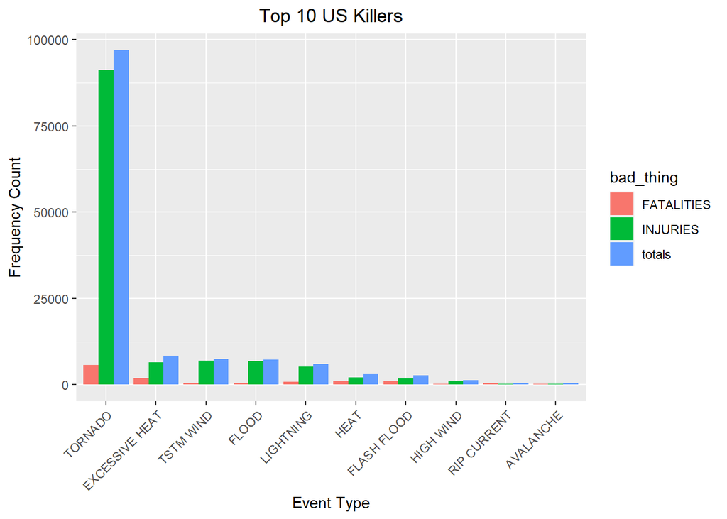

```r
library(ggplot2)
# Create a bar chart for top 10 US killers
healthChart <- ggplot(bad_stuff, aes(x = reorder(EVTYPE, -value),
    y = value))

# Plot data as bar chart
healthChart = healthChart + geom_bar(stat = "identity", aes(fill = bad_thing),
    position = "dodge")
# Format y-axis scale and set y-axis label
healthChart = healthChart + ylab("Frequency Count")
# Set x-axis label
healthChart = healthChart + xlab("Event Type")
# Rotate x-axis tick labels
healthChart = healthChart + theme(axis.text.x = element_text(angle = 45,
    hjust = 1))
# Set chart title and center it
healthChart = healthChart + ggtitle("Top 10 US Killers") + theme(plot.title = element_text(hjust = 0.5))

healthChart
```

So, Tornado is the most harmful event with a lot of injuries.

### 4.3 Identifying Events with Most Economic Impact

Before making bar graph, we will melt data.table for easy transformation

```r
econ_consequences <- melt(totalCostDT, id.vars = "EVTYPE", variable.name = "Damage_Type")
head(econ_consequences, 5)
```

| EVTYPE | Damage_Type | value |
| --- | --- | --- |
| TORNADO | PropCost | 41885103105 |
| HURRICANE/TYPHOON | PropCost | 32747770000 |
| FLOOD | PropCost | 6632851640 |
| TROPICAL STORM | PropCost | 6560156000 |
| WINTER STORM | PropCost | 5221162500 |

**Creating the Plot**

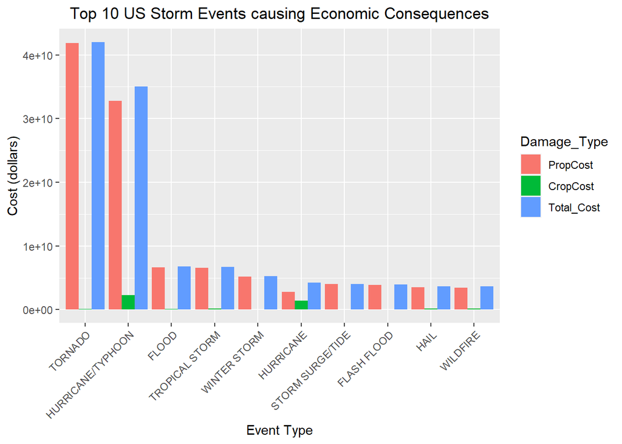

```r
# Create a bar chart for top 10 US storm events causing
# economic consequencs
econChart <- ggplot(econ_consequences, aes(x = reorder(EVTYPE,
    -value), y = value))

# Plot data as bar chart
econChart = econChart + geom_bar(stat = "identity", aes(fill = Damage_Type),
    position = "dodge")
# Format y-axis scale and set y-axis label
econChart = econChart + ylab("Cost (dollars)")
# Set x-axis label
econChart = econChart + xlab("Event Type")
# Rotate x-axis tick labels
econChart = econChart + theme(axis.text.x = element_text(angle = 45,
    hjust = 1))
# Set chart title and center it
econChart = econChart + ggtitle("Top 10 US Storm Events causing Economic Consequences") +
    theme(plot.title = element_text(hjust = 0.5))
econChart
```